# Computer Science 1

**Computer lab 09**

Author

Kálmán Abari

Published

September 5, 2026

Learning outcomes

Students will learn how to run descriptive analysis in *jamovi*.

# Jamovi - Descriptive statistics II.

## Problem 1

> In this section you will learn how to explore the distribution of categorical variables using graphical tools.

The `comics.omv` dataset has information on all comic characters that have been introduced by DC and Marvel (see Lab 08 - Problem 1).

1. Create a bar chart for the variables `align`, `gender` and `id`. Select `Analyses / Exploration / Descriptives` menu. To fully investigate **the distribution of categorical variables** (nominal or ordinal variables), we perform all three activities:
   - display valid and missing values
   - display frequency table
   - display a bar chart.

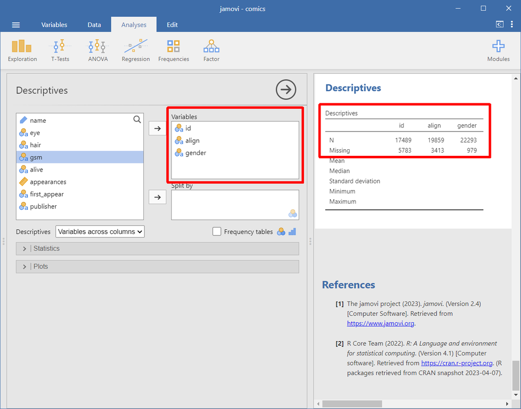

Valid and Missing values

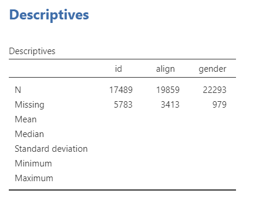

Valid and Missing values

[figure not shown]

Frequency tables

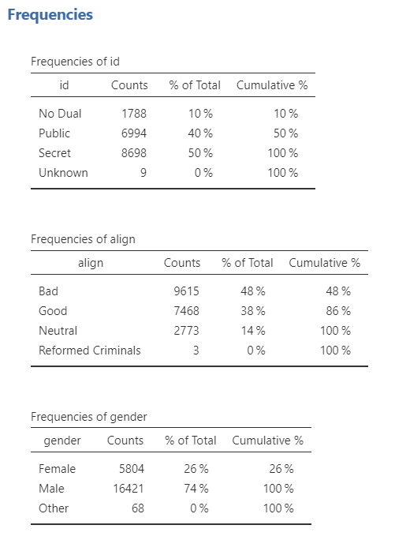

Frequency tables

[figure not shown]

Bar chart

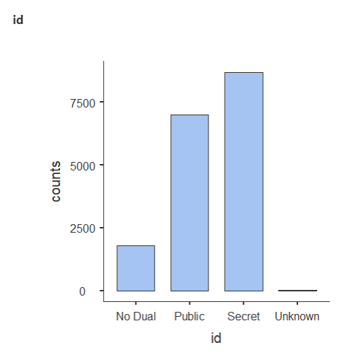

Bar chart for `id` variable

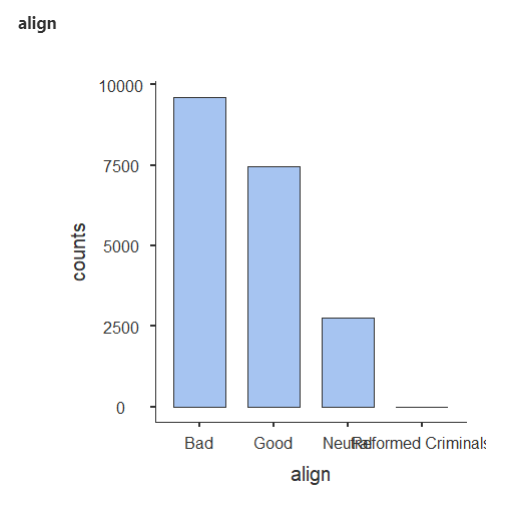

Bar chart for `align` variable

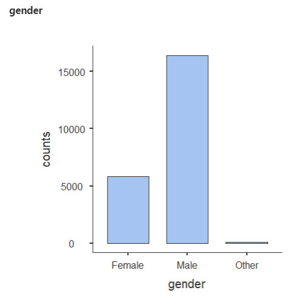

Bar chart for `gender` variable

As you can see, the bar plot provides the same information as the frequency table. The interpretation of the figures is simpler, but less accurate than the frequency table.

For example, the predominance of male characters among all the characters is very noticeable, as can be seen in the last picture. If we are interested in the exact numbers, we see that the 16421 male characters are 74% of all characters.

2. Save and send the file `comics.omv` to the `abari.kurzus@gmail.com`. The subject of this email is `Lab09 - Problem 1`.

**TipBar chart**

A bar chart is a graphical representation used to display the distribution or frequency of categorical data. It is a common and effective way to visualize and summarize the data for qualitative variables, which represent categories or groups rather than numerical values. Bar charts are particularly useful for comparing the relative frequencies or counts of different categories within a dataset.

Here are the key features and characteristics of a bar chart:

- Categorical Data: Bar charts are used to represent data with categorical variables, such as types of fruits, colors, survey responses (e.g., strongly agree, agree, neutral, disagree, strongly disagree), or any other non-numeric categories.
- Rectangular Bars: In a bar chart, each category is represented by a rectangular bar. The length or height of the bar is proportional to the frequency or count of that category in the dataset. In jamovi count is used.
- Categories on the X-Axis: The categories are typically displayed on the horizontal X-axis, making it easy to compare different groups. Each category is labeled on the X-axis, and the bars are positioned above or adjacent to the corresponding labels.
- Frequency on the Y-Axis: The frequency or count of each category is typically represented on the vertical Y-axis. The scale on the Y-axis depends on the range of the data, and it can be in the form of counts, percentages, or other relevant units.
- Bar Orientation: Bar charts can be either horizontal or vertical, depending on the data and the preferred presentation style. Vertical bar charts are more common, but horizontal bar charts are used when the category labels are long or when you want to emphasize differences in length more easily.

Bar charts are a straightforward and effective way to visualize categorical data, making it easy to compare the relative frequencies or counts of different categories within a dataset. They are commonly used for data presentation in reports, presentations, and publications, and they help provide a clear, visual summary of the distribution of categorical data.

## Problem 2

> In this section, you will learn how to explor 2 categorical data.

The `comics.omv` dataset has information on all comic characters that have been introduced by DC and Marvel (see Lab 08 - Problem 1).

A common way to represent the number of cases that fall into each combination of levels of **two categorical variables** (`align` and `id`) is with a **contingency table**.

1. Select `Analyses / Exploration / Descriptives` menu. Move the `align` variable to the ‘Variables’ box and the `id` variable to the ‘Split by’ box.

[figure not shown]

Contingency table

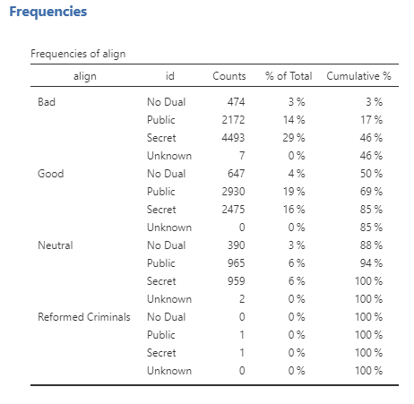

Contingency table

The output tells us that the most common category, at a count of 4493, was bad characters with secret identities. While tables of counts can be useful, you can get the bigger picture by translating these counts into a graphic.

2. We’re interested in the relationship between two categorical variables, which is represented well by a bar chart.

[figure not shown]

Bar chart for a contingency table

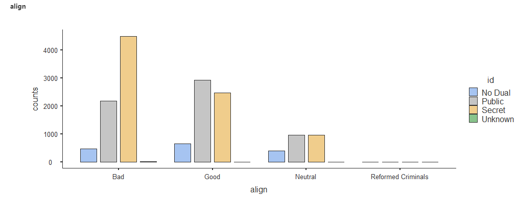

Bar chart for a contingency table

The X-axis of the bar chart above shows the alignments of the characters, and the colouring is based on identity. Since we have two categorical variables, the data are located along two dimensions (X-axis and colouring). It is also easy to see from the figure that most of them are bad characters with secret identities.

3. There is an even better contingency table drawing option in *jamovi* than the one seen before. Select `Analyses / Frequencies / Independent Samples` menu. Move the `align` variable to the ‘Rows’ field and the `id` variable to the ‘Columns’ field. Activate the ‘Rows’ check box on the ‘Cells’ tab and the ‘Bar Plot’ check box on the ‘Plots’ tab.

[figure not shown]

Contingency table

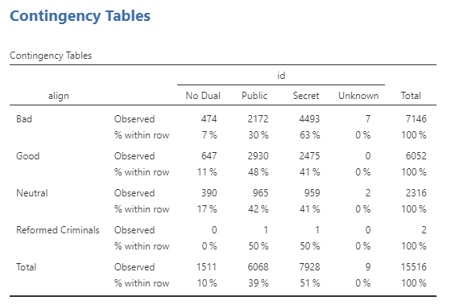

Contingency table

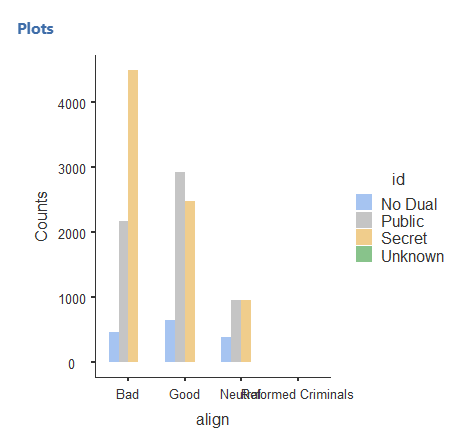

Bar chart for a contingency table

In the contingency table above, we see a little more information and in a different arrangement than in the previously created contingency table. Of course, it can also be seen from this contingency table that most of them are characters with bad, secret identities. However, thanks to the percentage values taken per line, we can also see that among the bad characters there is a predominance of people with a secret identity (63% of the bad characters have a secret identity), however, in the case of the other alignments, the public and secret identities are roughly balanced (Good: 48%-41%, Neutral 42%-41%, Reformed Criminals 50%-50%).

4. Save and send the file `comics.omv` to the `abari.kurzus@gmail.com`. The subject of this email is `Lab09 - Problem 2`.

**TipContingency table**

A contingency table, also known as a cross-tabulation or a two-way table, is a tabular representation used in descriptive statistics to summarize and display the relationships between two categorical variables. It provides a way to examine the distribution of one variable with respect to another or to assess the association, dependence, or independence between the variables. Contingency tables are especially useful when you want to analyze and visualize the relationship between two categorical variables and see how they are related or how they co-occur.

Key characteristics of a contingency table include:

- Rows and Columns: Contingency tables have rows and columns, each corresponding to different categories or levels of the two categorical variables being studied.
- Counts or Frequencies: The cells of the table contain counts or frequencies that represent the number of observations falling into each combination of categories from the two variables. The intersection of a row and a column represents a specific category combination.
- Marginal Totals: Contingency tables often include marginal totals, which are the sums of counts for each row and each column. These totals provide information about the overall distribution of each variable.
- Row and column percentages in a contingency table are ways to express the relative proportions and relationships between the categories of the variables being examined. They help to provide a more detailed and intuitive understanding of the distribution of data in the table. Row percentages and column percentages are calculated based on the counts or frequencies in the contingency table, and they are used to assess the relationships between the two categorical variables being studied.
  - Row Percentages, also known as conditional percentages, are calculated for each row in the contingency table. They express the proportion of cases in a specific row relative to the total number of cases in that row. The formula for row percentages is: (Count in a Specific Cell) / (Total Count in the Row) * 100%. Row percentages allow you to see how each category of one variable is distributed within the categories of the other variable. They help you understand the relative distribution of one variable within the context of the other.
  - Column percentages are calculated for each column in the contingency table. They express the proportion of cases in a specific column relative to the total number of cases in that column. The formula for column percentages is: (Count in a Specific Cell) / (Total Count in the Column) * 100%. Column percentages provide insights into how each category of one variable is distributed within the categories of the other variable. They help you assess how the distribution of one variable is related to the distribution of the other.

## Problem 3

> In this section, you will learn how to explore numerical data using graphical tools.

In this problem, we’ll broaden our tool box of exploratory techniques to encompass numerical data. Numerical data are data that take the form of number, but where those numbers actually represent a value on the number line. The dataset that we’ll be working with is one that has information on the cars that were for sale in the US in a certain year.

1. Open this [link](https://www.kaggle.com/code/joanpau/basic-eda-in-r-about-vehicles/input) and download the `Cars.csv` from there (or from [here](https://github.com/abarik/computer_science_1_2023_24_1/blob/0bc509cf034f1ff162759dec817ef3d87c09152f/files/Cars.csv)).
2. You can study the description of the database in the link above. Based on this, let’s set the variables.

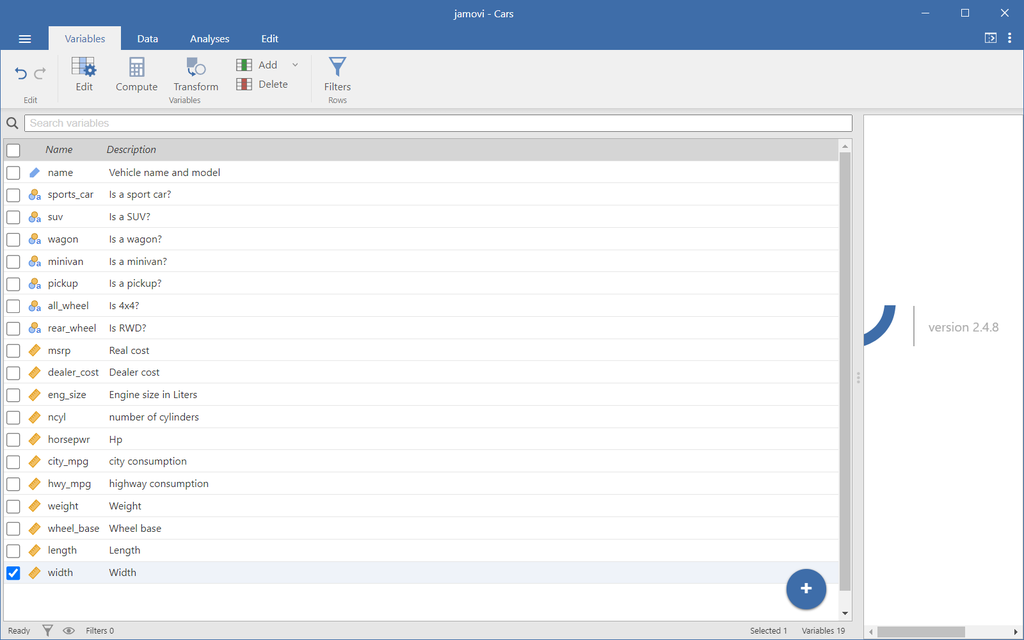

Review the variables

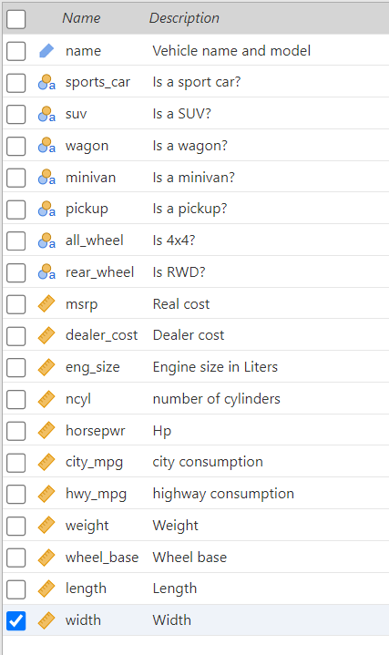

Review the variables

3. Learn that we have 428 observations, or cases, and 19 variables.

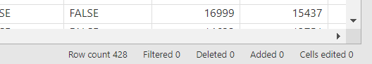

Number of rows (number of observations)

4. Learn more about each of the variables. Determine the number of valid and missing values for all variables. Choose a space-saving solution.

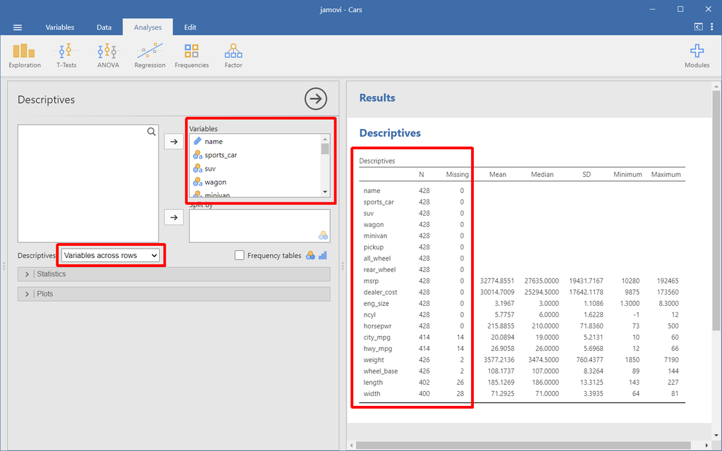

Valid and missing values

Move all variables to the `Variable` box. To save space, select the `Variable across rows` list item in the `Descriptives` list.

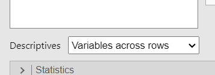

The `Variable across rows` list item

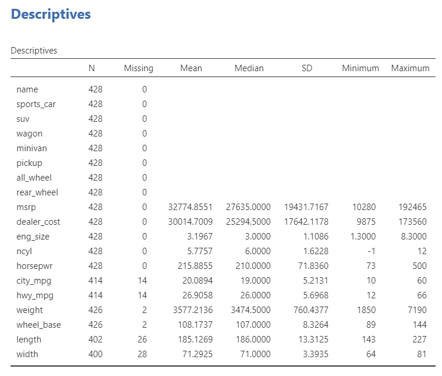

Valid and missing values

5. The most direct way to represent numerical data is a **dot plot**, where each case is a dot that’s placed at it’s appropriate value on the X-axis, then stacked as other cases take similar values. This is a form of graphic where there is zero information loss; you could actually rebuild the dataset perfectly if you were given this plot. As you can imagine, though, these plots start to get difficult to read as the number of cases gets very large. Let’s display a dot diagram of the number of cylinders (`ncyl`), horsepower (`horsepwr`) and city consumption (`city_mpg`) of the cars. Select `Analyses / Exploration / Descriptives` menu. Move the `ncyl`, `horsepwr`, and `city_mpg` variables to the ‘Variables’ box. On the ‘Plot’ tab, select the ‘Data’ checkbox and select the ‘Stacked’ item.

[figure not shown]

Display dot plot

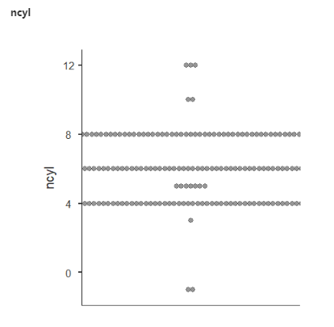

Dot plot for `ncyl`

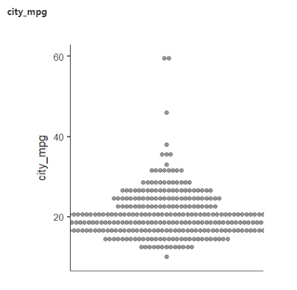

Dot plot for `city_mpg`

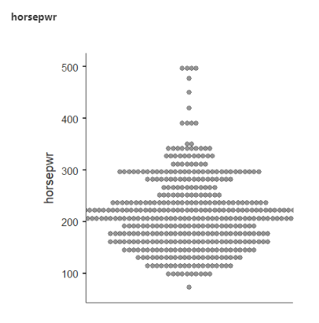

Dot plot for `horsepwr`

As we can see, the display of the dot plot in *jamovi* is not perfect, since the frequency of values with too high a frequency cannot be tracked due to the clipping of values beyond the margin. Nevertheless, we receive information that, for example, the values 4, 6 and 8 are the most common in the number of sounds, and most cars have a city consumption of around 20 and a horsepower of around 200.

**TipDot plot**

A dot plot, also known as a dot chart or dot graph, is a simple and straightforward graphical representation used in descriptive statistics to display the distribution of a numerical variable. It is particularly useful for visualizing the distribution of numerical data, showing individual data points as dots along a single axis. Each dot represents a single data point, and the arrangement of the dots provides a clear view of the data’s distribution.

Key features of a dot plot include:

- Individual Data Points: In a dot plot, each data point is represented by a dot placed at the appropriate position along a numerical axis. The vertical or horizontal axis can represent the variable being measured.
- Stacking Dots: When multiple data points have the same value, the dots are stacked vertically on top of one another at the corresponding value on the axis. This stacking allows you to see the frequency of data points at each value.
- Symmetry and Clustering: Dot plots can reveal patterns in the data, such as symmetry, skewness, gaps, clusters, or outliers. The arrangement of dots provides insights into the data’s central tendency and spread.
- Simplicity: Dot plots are relatively simple to create and interpret, making them a useful tool for quick data exploration and comparison.
6. One of the most common plots to use is a **histogram**, which is mapping the height of the bar to the number of cases that fall into that bin. Because of the binning, it’s not possible to perfectly reconstruct the dataset: what we gain is a bigger picture of the shape of the distribution. If the stepwise nature of the histogram irks you, then you’ll like the **density plot**. The density plot represents the shape of the histogram using a smooth line. This provides an ever bigger picture representation of the shape of the distribution, so you’ll only want to use it when you have a large number of cases. Values from variables can be used to construct a **boxplot**, where the box represents the central bulk of the data, the whiskers contain almost all the data, and the extreme values are represented as points.

We will investigate the distribution of mileage (`city_mpg`) across a categorical variable. (The higher the city MPG, the more miles you can travel on the same amount of fuel, resulting in better overall mileage for your vehicle.) First, plot a histogram of `city_mpg` faceted by `suv`, a logical variable indicating whether the car is an SUV or not. Select `Analyses / Exploration / Descriptives` menu. Move the `city_mpg` variable to the ‘Variables’ box and the `suv` variable to the ‘Split by’ box.

[figure not shown]

Histogram for mileage (`city_mpg`)

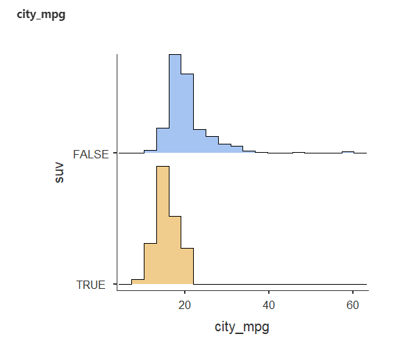

Histogram for mileage (`city_mpg`)

If we compare the midpoints of each area, we can see that SUVs have slightly worse mileage.